# EDA dataset

Cheloshkina K

14 09 2019

```r
sprintf("This markdown shows exploratory analysis of dataset for window length of %s bases.", format(win_len, big.mark = " ", scientific = FALSE))
```

```
[1] "This markdown shows exploratory analysis of dataset for window length of 100 000 bases."
```

## Hotspots statistics

Number of labeling strategies for each cancer type:

```r
hsp_cols <- grep(x = names(data), pattern = "hsp",value = TRUE)
hsp_stats <- data.frame(hsp_name = hsp_cols, stringsAsFactors = FALSE)
hsp_stats$level <- unlist(lapply(strsplit(x = hsp_stats$hsp_name, split = "_"),
                                 function(x) x[2]))
hsp_stats$cancer_type <- unlist(lapply(strsplit(x = hsp_stats$hsp_name, split = "_"),
                                       function(x) x[3]))

hsp_stats %>%
  group_by(cancer_type) %>%
  summarize(n_hotspot_types = n())
```

| cancer_type | n_hotspot_types |
| --- | --- |
| blood | 6 |
| bone | 6 |
| brain | 6 |
| breast | 6 |
| liver | 6 |
| ovary | 6 |
| pancreatic | 6 |
| prostate | 6 |
| skin | 6 |
| uterus | 6 |

Number of hotspots for each cancer type and labeling strategy.

```r
n_hotspots <- data %>%
  summarize_at(hsp_cols, sum) %>%
  t() %>%
  data.frame()

names(n_hotspots) <- "n_hotspots"
n_hotspots$hsp_name <- rownames(n_hotspots)
rownames(n_hotspots)<- NULL

n_hotspots <- n_hotspots %>%
  inner_join(hsp_stats, by = "hsp_name")

dcast(data = n_hotspots, formula = cancer_type ~ level, value.var = "n_hotspots")
```

| cancer_type | 99. | 99.5. | 99.9. | 99.95. | 99.99. | all |
| --- | --- | --- | --- | --- | --- | --- |
| blood | 284 | 147 | 26 | 15 | 3 | 1318 |
| bone | 288 | 142 | 30 | 15 | 3 | 1159 |
| brain | 289 | 142 | 21 | 12 | 2 | 818 |
| breast | 293 | 147 | 29 | 15 | 2 | 26246 |
| liver | 291 | 144 | 28 | 13 | 3 | 10771 |
| ovary | 291 | 134 | 27 | 15 | 3 | 19936 |
| pancreatic | 293 | 145 | 30 | 15 | 3 | 22218 |
| prostate | 293 | 147 | 29 | 15 | 3 | 25368 |
| skin | 290 | 146 | 29 | 15 | 3 | 16397 |
| uterus | 292 | 140 | 30 | 15 | 3 | 5226 |

Here is a distribution of “all” hotspots among chromosomes for different cancer types.

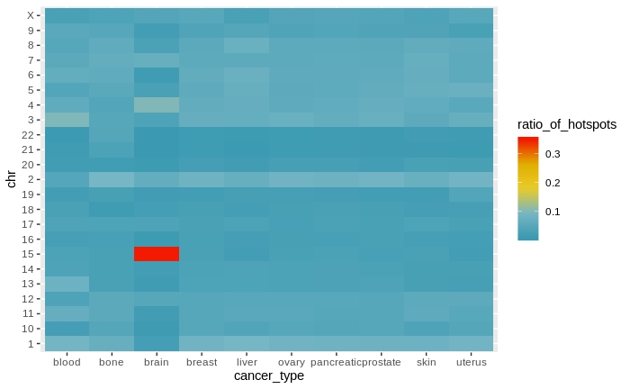

```r
hsp_all <- grep(x = hsp_cols, pattern = "all", value = TRUE)

chr_stats <- data %>%
  group_by(chr) %>%
  summarize_at(hsp_all, sum)

total_hsp <- chr_stats %>%
  summarize_at(hsp_all, sum)

for (col in hsp_all){
  chr_stats[col] <- chr_stats[col] / as.numeric(total_hsp[col][1])
}

melted_chr_stats <- melt(chr_stats, id.vars = "chr")
melted_chr_stats$variable <- gsub(x = melted_chr_stats$variable,
                                  pattern = "hsp_all_", replacement = "")
names(melted_chr_stats) <- c("chr", "cancer_type", "ratio_of_hotspots")

ggplot(melted_chr_stats, aes(cancer_type, chr)) +
  geom_tile(aes(fill = ratio_of_hotspots)) + scale_fill_gradientn(colours = pal)
```

Let’s discover if there are cancer types which have the same hotspots for given ratio of windows marked as hotspots.

```r
dupl_cols <- duplicated(t(data[hsp_cols]))

if (any(dupl_cols)){
  dupl_cols <- hsp_cols[dupl_cols]
  duplicates <- list()
  for (dupl_col in dupl_cols){
    for (col in setdiff(hsp_cols, c(dupl_cols))){
      ifelse(all(data[col] == data[dupl_col]),
             duplicates[dupl_col] <- col, FALSE)
    }
  }
  print(duplicates)
}
```

## Features statistics

Conserved features (do not depend on tissue type):

```r
feat_names <- setdiff(names(data), c("chr","from","to", hsp_cols))
tissue_spec_feats <- grep(x = feat_names, pattern = "cancer", value = TRUE)
conserved_feats <- setdiff(feat_names, tissue_spec_feats)
print(length(feat_names))
```

```
[1] 75
```

```r
conserved_feats
```

```
 [1] "A_Phased_Repeat"           "Direct_Repeat"             "Inverted_Repeat"
 [4] "Mirror_Repeat"             "Short_Tandem_Repeat"       "G_quadruplex"
 [7] "stemloops_16_50"           "stemloops_6_15"            "X3UTR"
[10] "X5UTR"                     "codingExons"               "downstream"
[13] "introns"                   "promoters"                 "WholeGenes"
[16] "tad_boundaries_liver"      "tad_boundaries_ovary"      "tad_boundaries_pancreatic"
[19] "Z_DNA_Motif"
```

Tissue-specific features:

```r
un_tissue_spec_feats <- unique(unlist(lapply(
  strsplit(x = tissue_spec_feats, split = "_"),
  function(x) paste(x[3:length(x)], collapse = "_")
)))
un_tissue_spec_feats
```

```
 [1] "DNase_seq"       "DNA_methylation" "H3K27ac.human"   "H3K27me3.human"
 [5] "H3K36me3.human"  "H3K4me1.human"   "H3K4me3.human"   "H3K9me3.human"
 [9] "ATF3.human"      "CTCF.human"      "EGR1.human"      "FOXA1.human"
[13] "FOXA2.human"     "GABPA.human"     "HNF4A.human"     "HNF4G.human"
[17] "JUND.human"      "MAX.human"       "NR2F2.human"     "REST.human"
[21] "RXRA.human"      "SP1.human"       "YY1.human"       "ZBTB33.human"
```

```r
unique(hsp_stats$cancer_type)
```

```
 [1] "blood"      "bone"       "brain"      "breast"     "liver"      "ovary"
 [7] "pancreatic" "prostate"   "skin"       "uterus"
```

```r
l <- lapply(
  strsplit(x = tissue_spec_feats, split = "_"),
  function(x) c(x[2], paste(x[3:length(x)], collapse = "_")
))

df <- data.frame(do.call("rbind", l))
names(df) <- c("cancer_type", "feature")
df$value <- "+"
dcast(df, formula = feature ~ cancer_type, value.var = "value")
```

| feature | blood | bone | brain | breast | liver | ovary | pancreas | prostate | skin | uterus |
| --- | --- | --- | --- | --- | --- | --- | --- | --- | --- | --- |
| ATF3.human | NA | NA | NA | NA | + | NA | NA | NA | NA | NA |
| CTCF.human | NA | NA | NA | NA | + | NA | + | NA | NA | NA |
| DNA_methylation | NA | NA | + | + | + | NA | + | NA | + | + |
| DNase_seq | + | + | + | + | + | + | + | + | + | + |
| EGR1.human | NA | NA | NA | NA | + | NA | NA | NA | NA | NA |
| FOXA1.human | NA | NA | NA | NA | + | NA | NA | NA | NA | NA |
| FOXA2.human | NA | NA | NA | NA | + | NA | NA | NA | NA | NA |
| GABPA.human | NA | NA | NA | NA | + | NA | NA | NA | NA | NA |
| H3K27ac.human | + | NA | + | NA | + | NA | + | NA | NA | + |
| H3K27me3.human | + | NA | + | NA | NA | NA | NA | NA | NA | NA |

[output cut: 14 more lines]

```r
NA
```

```r
new_conserved <- c(
  "A_Phased_Repeat", "Direct_Repeat",
  "Inverted_Repeat", "Mirror_Repeat", "Short_Tandem_Repeat",
  "Z_DNA_Motif", "G_quadruplex",
  "stemloops_16_50", "stemloops_6_15",
  "X3UTR", "X5UTR", "codingExons", "downstream", "introns", "promoters", "WholeGenes",
  "tad_boundaries_liver", "tad_boundaries_ovary", "tad_boundaries_pancreatic",

  "cancer_liver_ATF3.human", "cancer_liver_CTCF.human", "cancer_liver_EGR1.human",
  "cancer_liver_FOXA1.human", "cancer_liver_FOXA2.human", "cancer_liver_GABPA.human",
  "cancer_liver_HNF4A.human", "cancer_liver_HNF4G.human", "cancer_liver_JUND.human",
  "cancer_liver_MAX.human", "cancer_liver_NR2F2.human", "cancer_liver_REST.human",
  "cancer_liver_RXRA.human", "cancer_liver_SP1.human", "cancer_liver_YY1.human",
  "cancer_liver_ZBTB33.human"
)

new_tissue_spec <- setdiff(feat_names, new_conserved)
```

Correlations between features:

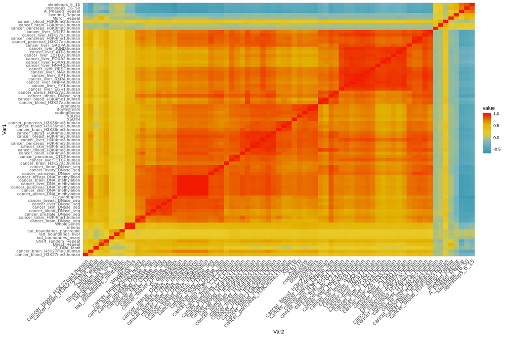

```r
cormat <- round(cor(data[feat_names], method = "spearman"), 2)

reorder_cormat <- function(cormat){
  dd <- as.dist((1-cormat)/2)
  hc <- hclust(dd)
  cormat <- cormat[hc$order, hc$order]
}
cormat <- reorder_cormat(cormat)
melted_cormat <- melt(cormat, na.rm = TRUE)

ggplot(melted_cormat, aes(Var2, Var1, fill = value))+
  geom_tile()+
  theme_minimal()+ # minimal theme
  theme(axis.text.x = element_text(angle = 45, vjust = 1,
    size = 12, hjust = 1))  + scale_fill_gradientn(colours = pal)
```

Distribution of correlation value of all pairs of features

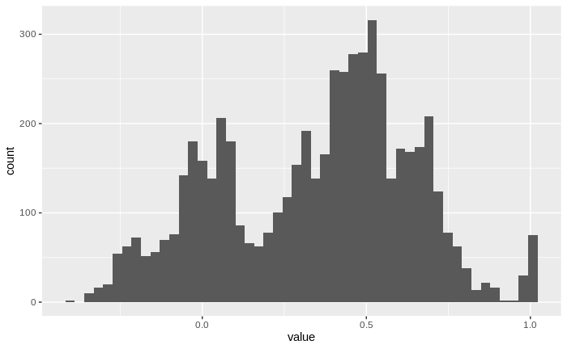

```r
ggplot(melted_cormat, aes(value)) +
  geom_histogram(bins = 50)
```

Distribution of mean correlation between groups of features

```r
feat_groups <- data.frame(
  feat = c("A_Phased_Repeat","Direct_Repeat", "Inverted_Repeat", "Mirror_Repeat","Short_Tandem_Repeat",
             "G_quadruplex", "stemloops_16_50", "stemloops_6_15", "Z_DNA_Motif"),
  feat_group = "sec_str"
)
feat_groups <- rbind(feat_groups, data.frame(
  feat = c("X3UTR", "X5UTR", "codingExons", "downstream", "introns", "promoters", "WholeGenes"),
  feat_group = "reg"
))
feat_groups <- rbind(feat_groups, data.frame(
  feat = c("tad_boundaries_liver", "tad_boundaries_ovary", "tad_boundaries_pancreatic"),
  feat_group = "tad"
))
feat_groups <- rbind(feat_groups, data.frame(
  feat = c("cancer_skin_DNase_seq", "cancer_brain_DNase_seq", "cancer_blood_DNase_seq",
              "cancer_prostate_DNase_seq", "cancer_pancreas_DNase_seq", "cancer_ovary_DNase_seq",
              "cancer_liver_DNase_seq", "cancer_breast_DNase_seq", "cancer_uterus_DNase_seq",
              "cancer_bone_DNase_seq"),
  feat_group = "chromatin"
))
feat_groups <- rbind(feat_groups, data.frame(
  feat = c("cancer_brain_DNA_methylation", "cancer_breast_DNA_methylation",
            "cancer_liver_DNA_methylation", "cancer_pancreas_DNA_methylation",
            "cancer_skin_DNA_methylation", "cancer_uterus_DNA_methylation"),
  feat_group = "methyl"
))
feat_groups <- rbind(feat_groups, data.frame(
  feat = c( "cancer_liver_H3K27ac.human", "cancer_uterus_H3K27ac.human", "cancer_blood_H3K27ac.human",
               "cancer_brain_H3K27ac.human",
               "cancer_pancreas_H3K27ac.human","cancer_blood_H3K27me3.human","cancer_brain_H3K27me3.human",
               "cancer_blood_H3K36me3.human","cancer_pancreas_H3K36me3.human","cancer_brain_H3K36me3.human",
               "cancer_pancreas_H3K4me1.human","cancer_blood_H3K4me1.human","cancer_brain_H3K4me1.human",
               "cancer_breast_H3K4me3.human","cancer_uterus_H3K4me3.human","cancer_liver_H3K4me3.human",
               "cancer_brain_H3K4me3.human","cancer_blood_H3K4me3.human","cancer_skin_H3K4me3.human",
               "cancer_pancreas_H3K4me3.human","cancer_brain_H3K9me3.human","cancer_pancreas_H3K9me3.human",
               "cancer_blood_H3K9me3.human" ),
  feat_group = "histones"
))
feat_groups <- rbind(feat_groups, data.frame(
  feat = c("cancer_liver_ATF3.human", "cancer_liver_CTCF.human", "cancer_pancreas_CTCF.human",
        "cancer_liver_EGR1.human", "cancer_liver_FOXA1.human", "cancer_liver_FOXA2.human",
        "cancer_liver_GABPA.human","cancer_liver_HNF4A.human", "cancer_liver_HNF4G.human",
        "cancer_liver_JUND.human","cancer_liver_MAX.human", "cancer_liver_NR2F2.human",
        "cancer_liver_REST.human", "cancer_liver_RXRA.human", "cancer_liver_SP1.human",
        "cancer_liver_YY1.human", "cancer_liver_ZBTB33.human"),
  feat_group = "tf"
))

melted_cormat <- melted_cormat %>%
  inner_join(feat_groups, by=c("Var1" = "feat")) %>%
  rename("feat_group1" = "feat_group") %>%
  inner_join(feat_groups, by=c("Var2" = "feat")) %>%
  rename("feat_group2" = "feat_group")
```

```
Column `Var1`/`feat` joining factors with different levels, coercing to character vectorColumn `Var2`/`feat` joining factors with different levels, coercing to character vector
```

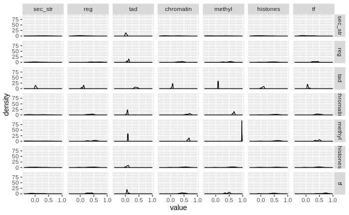

```r
melted_cormat <- melted_cormat[melted_cormat$Var1 != melted_cormat$Var2, ]
ggplot(data=melted_cormat, aes(value))+
  geom_density()+
  facet_grid(feat_group1 ~ feat_group2)
```

```r
feat_group_stats <- melted_cormat %>%
  group_by(feat_group1, feat_group2) %>%
  summarize(
    q1 = quantile(value, 0.25),
    q2 = quantile(value, 0.5),
    q3 = quantile(value, 0.75)
  )

feat_group_stats %>%
  filter(feat_group1 == feat_group2) %>%
  arrange(q1)
```

| feat_group1 | feat_group2 | q1 | q2 | q3 |
| --- | --- | --- | --- | --- |
| sec_str | sec_str | 0.0025 | 0.26 | 0.4125 |
| histones | histones | 0.0700 | 0.52 | 0.6500 |
| tad | tad | 0.3525 | 0.39 | 0.4350 |
| reg | reg | 0.4100 | 0.59 | 0.7500 |
| tf | tf | 0.5675 | 0.70 | 0.7600 |
| chromatin | chromatin | 0.6100 | 0.69 | 0.7200 |
| methyl | methyl | 0.9700 | 0.97 | 0.9700 |

```r
feat_group_stats %>%
  filter(feat_group1 != feat_group2) %>%
  arrange(feat_group1, q1)
```

| feat_group1 | feat_group2 | q1 | q2 | q3 |
| --- | --- | --- | --- | --- |
| sec_str | methyl | -0.2700 | 0.070 | 0.3975 |
| sec_str | chromatin | -0.2175 | 0.010 | 0.3100 |
| sec_str | histones | -0.1400 | 0.010 | 0.2200 |
| sec_str | tf | -0.1400 | -0.030 | 0.2000 |
| sec_str | reg | -0.0650 | 0.010 | 0.2000 |
| sec_str | tad | 0.0050 | 0.020 | 0.0400 |
| reg | sec_str | -0.0650 | 0.010 | 0.2000 |
| reg | tad | 0.0600 | 0.120 | 0.1200 |
| reg | tf | 0.2700 | 0.340 | 0.4150 |
| reg | histones | 0.2800 | 0.420 | 0.5200 |

[output cut: 32 more lines]

```r
feat_group_stats %>%
  filter(feat_group1 != feat_group2) %>%
  group_by(feat_group1) %>%
  filter(q3 == max(q3)) %>%
  select(-c("q1", "q2")) %>%
  arrange(q3)
```

| feat_group1 | feat_group2 | q3 |
| --- | --- | --- |
| tad | reg | 0.1200 |
| sec_str | methyl | 0.3975 |
| tf | histones | 0.5400 |
| reg | methyl | 0.5800 |
| histones | methyl | 0.6800 |
| chromatin | methyl | 0.6900 |
| methyl | chromatin | 0.6900 |

```r
feat_group_stats %>%
  filter(feat_group1 != feat_group2) %>%
  group_by(feat_group1) %>%
  filter(q1 == max(q1)) %>%
  select(-c("q3", "q2")) %>%
  arrange(q1)
```

| feat_group1 | feat_group2 | q1 |
| --- | --- | --- |
| sec_str | tad | 0.005 |
| tad | methyl | 0.080 |
| reg | chromatin | 0.290 |
| tf | chromatin | 0.390 |
| histones | methyl | 0.460 |
| chromatin | methyl | 0.640 |
| methyl | chromatin | 0.640 |

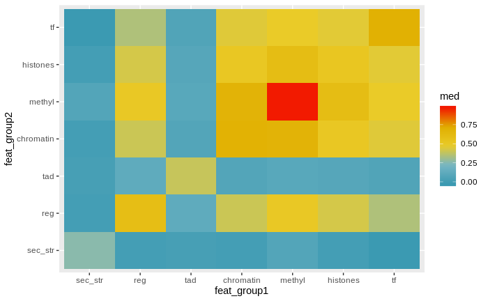

```r
feat_group_stats %>%
  group_by(feat_group1,feat_group2) %>%
  summarize(med = median(q2)) %>%
  ggplot(aes(x=feat_group1, y=feat_group2, fill=med)) + geom_tile()  + scale_fill_gradientn(colours = pal)
```

Distribution of features

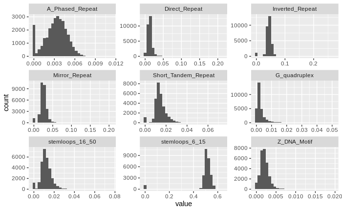

```r
feat_melted <- melt(data[feat_names])
sec_str <- c("A_Phased_Repeat", "Direct_Repeat",
  "Inverted_Repeat", "Mirror_Repeat", "Short_Tandem_Repeat",
  "Z_DNA_Motif", "G_quadruplex",
  "stemloops_16_50", "stemloops_6_15")

ggplot(feat_melted[feat_melted$variable %in% sec_str, ], aes(value)) +
  geom_histogram(bins=30) +
  facet_wrap(~ variable, scales = "free", nrow = 3)
```

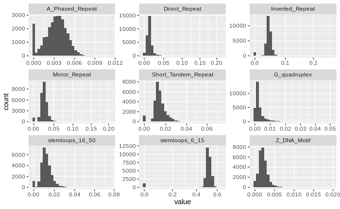

```r
ggplot(feat_melted[feat_melted$variable %in% sec_str, ], aes(value)) +
  geom_histogram(bins=30) +
  facet_wrap(~ variable, scales = "free", nrow = 3) +
  scale_x_continuous(trans = 'log1p')
```

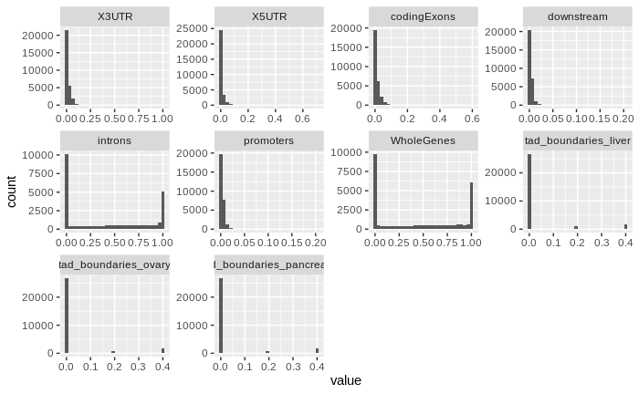

```r
reg_tad <- c(
  "X3UTR", "X5UTR", "codingExons", "downstream", "introns", "promoters", "WholeGenes",
  "tad_boundaries_liver", "tad_boundaries_ovary", "tad_boundaries_pancreatic")

ggplot(feat_melted[feat_melted$variable %in% reg_tad, ], aes(value)) +
  geom_histogram(bins=30) +
  facet_wrap(~ variable, scales = "free", nrow = 3)
```

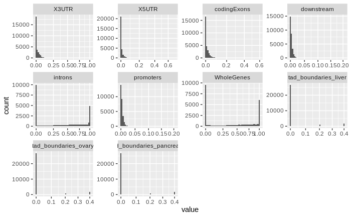

```r
ggplot(feat_melted[feat_melted$variable %in% reg_tad, ], aes(value)) +
  geom_histogram(bins=50) +
  facet_wrap(~ variable, scales = "free", nrow = 3)  +
  scale_x_continuous(trans = 'log1p')
```

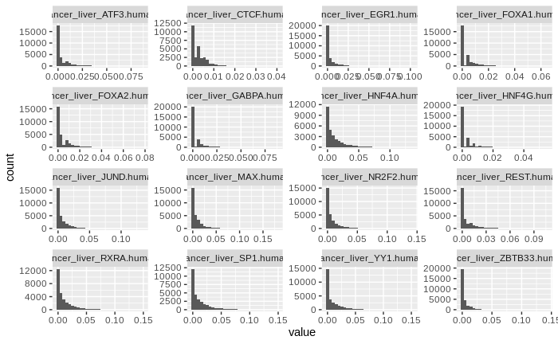

```r
tf <- c(
  "cancer_liver_ATF3.human", "cancer_liver_CTCF.human", "cancer_liver_EGR1.human",
  "cancer_liver_FOXA1.human", "cancer_liver_FOXA2.human", "cancer_liver_GABPA.human",
  "cancer_liver_HNF4A.human", "cancer_liver_HNF4G.human", "cancer_liver_JUND.human",
  "cancer_liver_MAX.human", "cancer_liver_NR2F2.human", "cancer_liver_REST.human",
  "cancer_liver_RXRA.human", "cancer_liver_SP1.human", "cancer_liver_YY1.human",
  "cancer_liver_ZBTB33.human")

ggplot(feat_melted[feat_melted$variable %in% tf, ], aes(value)) +
  geom_histogram(bins=30) +
  facet_wrap(~ variable, scales = "free", nrow = 4)
```

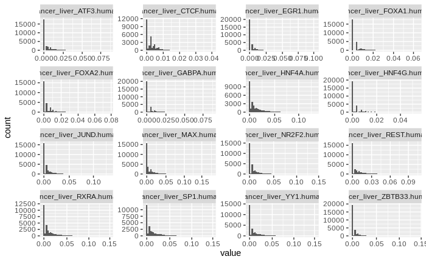

```r
ggplot(feat_melted[feat_melted$variable %in% tf, ], aes(value)) +
  geom_histogram(bins=50) +
  facet_wrap(~ variable, scales = "free", nrow = 4)  +
  scale_x_continuous(trans = 'log1p')
```

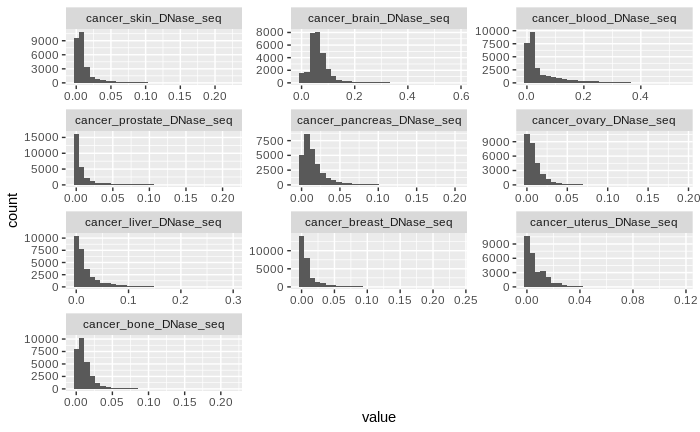

```r
dnase <- c(
  "cancer_skin_DNase_seq", "cancer_brain_DNase_seq", "cancer_blood_DNase_seq",
  "cancer_prostate_DNase_seq", "cancer_pancreas_DNase_seq", "cancer_ovary_DNase_seq",
  "cancer_liver_DNase_seq", "cancer_breast_DNase_seq", "cancer_uterus_DNase_seq",
  "cancer_bone_DNase_seq")

ggplot(feat_melted[feat_melted$variable %in% dnase, ], aes(value)) +
  geom_histogram(bins=30) +
  facet_wrap(~ variable, scales = "free", nrow = 4)
```

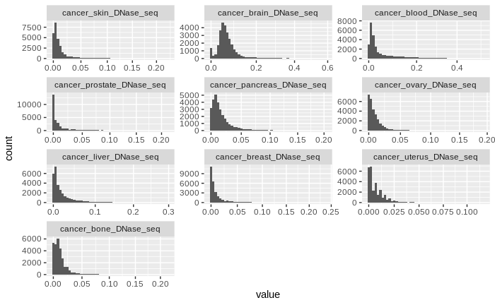

```r
ggplot(feat_melted[feat_melted$variable %in% dnase, ], aes(value)) +
  geom_histogram(bins=50) +
  facet_wrap(~ variable, scales = "free", nrow = 4)  +
  scale_x_continuous(trans = 'log1p')
```

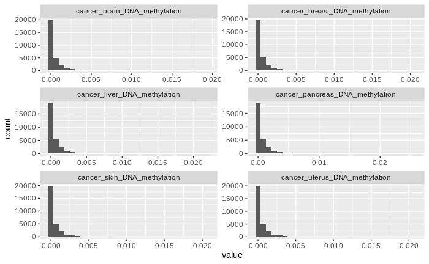

```r
meth <- c(
  "cancer_brain_DNA_methylation", "cancer_breast_DNA_methylation",
  "cancer_liver_DNA_methylation", "cancer_pancreas_DNA_methylation",
  "cancer_skin_DNA_methylation", "cancer_uterus_DNA_methylation")

ggplot(feat_melted[feat_melted$variable %in% meth, ], aes(value)) +
  geom_histogram(bins=30) +
  facet_wrap(~ variable, scales = "free", nrow = 4)
```

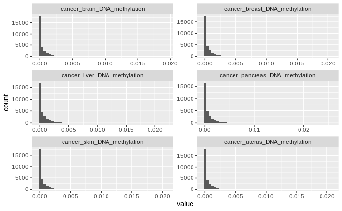

```r
ggplot(feat_melted[feat_melted$variable %in% meth, ], aes(value)) +
  geom_histogram(bins=50) +
  facet_wrap(~ variable, scales = "free", nrow = 4)  +
  scale_x_continuous(trans = 'log1p')
```

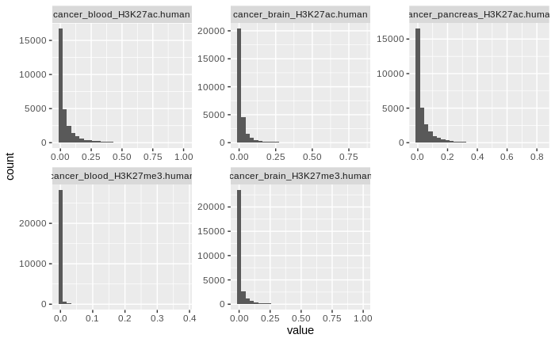

```r
h27 <- c(
   "cancer_blood_H3K27ac.human","cancer_brain_H3K27ac.human",
   "cancer_pancreas_H3K27ac.human", "cancer_blood_H3K27me3.human", "cancer_brain_H3K27me3.human")

ggplot(feat_melted[feat_melted$variable %in% h27, ], aes(value)) +
  geom_histogram(bins=30) +
  facet_wrap(~ variable, scales = "free", nrow = 2)
```

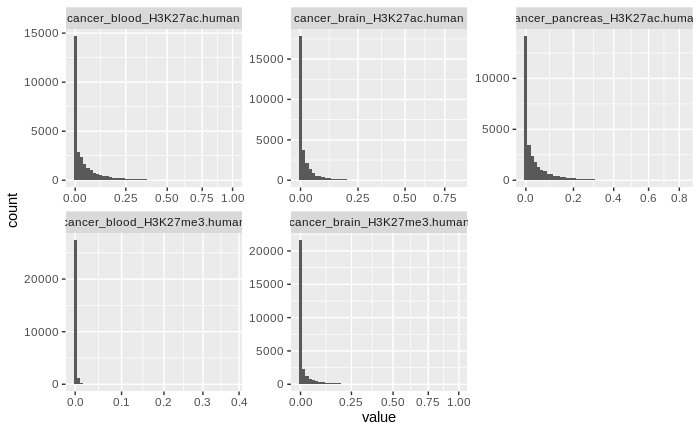

```r
ggplot(feat_melted[feat_melted$variable %in% h27, ], aes(value)) +
  geom_histogram(bins=50) +
  facet_wrap(~ variable, scales = "free", nrow = 2)  +
  scale_x_continuous(trans = 'log1p')
```

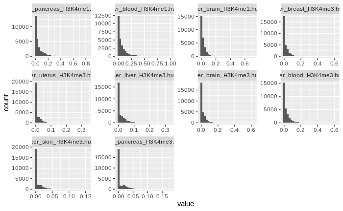

```r
hk4 <- c(
  "cancer_pancreas_H3K4me1.human", "cancer_blood_H3K4me1.human", "cancer_brain_H3K4me1.human",
  "cancer_breast_H3K4me3.human", "cancer_uterus_H3K4me3.human", "cancer_liver_H3K4me3.human",
  "cancer_brain_H3K4me3.human", "cancer_blood_H3K4me3.human", "cancer_skin_H3K4me3.human",
  "cancer_pancreas_H3K4me3.human"  )

ggplot(feat_melted[feat_melted$variable %in% hk4, ], aes(value)) +
  geom_histogram(bins=30) +
  facet_wrap(~ variable, scales = "free", nrow = 3)
```

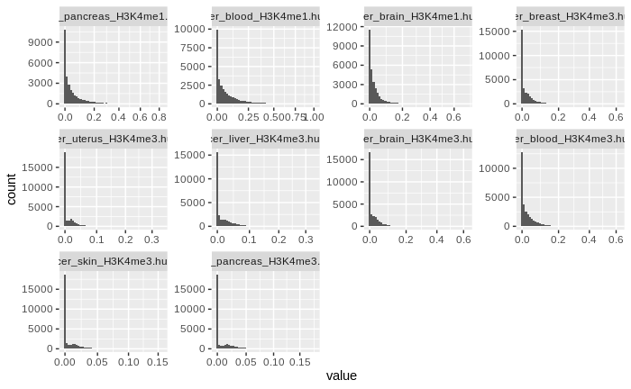

```r
ggplot(feat_melted[feat_melted$variable %in% hk4, ], aes(value)) +
  geom_histogram(bins=50) +
  facet_wrap(~ variable, scales = "free", nrow = 3)  +
  scale_x_continuous(trans = 'log1p')
```

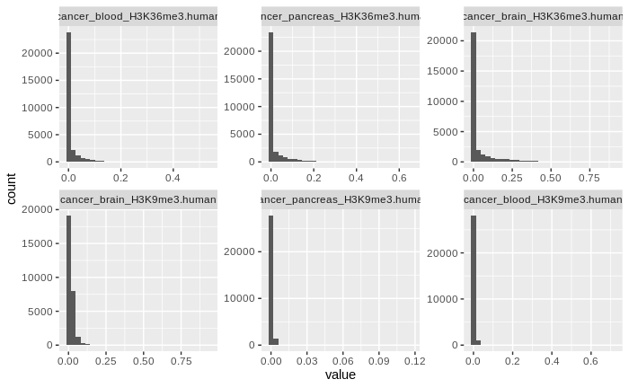

```r
hrest <- c(
  "cancer_blood_H3K36me3.human", "cancer_pancreas_H3K36me3.human", "cancer_brain_H3K36me3.human",
  "cancer_brain_H3K9me3.human", "cancer_pancreas_H3K9me3.human", "cancer_blood_H3K9me3.human")

ggplot(feat_melted[feat_melted$variable %in% hrest, ], aes(value)) +
  geom_histogram(bins=30) +
  facet_wrap(~ variable, scales = "free", nrow = 2)
```

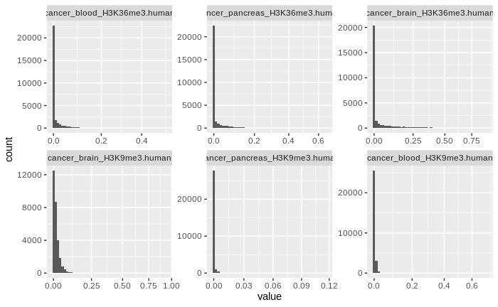

```r
ggplot(feat_melted[feat_melted$variable %in% hrest, ], aes(value)) +
  geom_histogram(bins=50) +
  facet_wrap(~ variable, scales = "free", nrow = 2)  +
  scale_x_continuous(trans = 'log1p')
```

For 1 Mb windows and 99.99 there is only 1 hotspot for each cancer type. Interestingly,it is the same window for blood, bone,breast, ovary and uterus cancer.

```r
# load 1Mb data
data <- read.csv("../data/datasets/dataset_1000000.csv")

hsp <- data[data$hsp_99.99._blood == 1, ]

hsp_cols <- grep(x = names(data), pattern = "hsp",value = TRUE)
feat_names <- setdiff(names(data), c(hsp_cols, "chr", "from", "to"))
hs_q <- data.frame()
for (f in feat_names){
  cf <- ecdf(as.vector(data[, f]))
  q <- cf(as.numeric(hsp[f]))
  hs_q <- rbind(hs_q, data.frame('feat' = f, 'q' = q))
}

sec_str <- c("A_Phased_Repeat","Direct_Repeat", "Inverted_Repeat", "Mirror_Repeat","Short_Tandem_Repeat",
             "G_quadruplex", "stemloops_16_50", "stemloops_6_15", "Z_DNA_Motif" )
reg <- c("X3UTR", "X5UTR", "codingExons", "downstream", "introns", "promoters", "WholeGenes")
tad <- c("tad_boundaries_liver", "tad_boundaries_ovary", "tad_boundaries_pancreatic")

chromatin <-c("cancer_skin_DNase_seq", "cancer_brain_DNase_seq", "cancer_blood_DNase_seq",
              "cancer_prostate_DNase_seq", "cancer_pancreas_DNase_seq", "cancer_ovary_DNase_seq",
              "cancer_liver_DNase_seq", "cancer_breast_DNase_seq", "cancer_uterus_DNase_seq",
              "cancer_bone_DNase_seq")
methyl <- c("cancer_brain_DNA_methylation", "cancer_breast_DNA_methylation",
            "cancer_liver_DNA_methylation", "cancer_pancreas_DNA_methylation",
            "cancer_skin_DNA_methylation", "cancer_uterus_DNA_methylation")
histones <- c( "cancer_liver_H3K27ac.human", "cancer_uterus_H3K27ac.human", "cancer_blood_H3K27ac.human",
               "cancer_brain_H3K27ac.human",
               "cancer_pancreas_H3K27ac.human","cancer_blood_H3K27me3.human","cancer_brain_H3K27me3.human",
               "cancer_blood_H3K36me3.human","cancer_pancreas_H3K36me3.human","cancer_brain_H3K36me3.human",
               "cancer_pancreas_H3K4me1.human","cancer_blood_H3K4me1.human","cancer_brain_H3K4me1.human",
               "cancer_breast_H3K4me3.human","cancer_uterus_H3K4me3.human","cancer_liver_H3K4me3.human",
               "cancer_brain_H3K4me3.human","cancer_blood_H3K4me3.human","cancer_skin_H3K4me3.human",
               "cancer_pancreas_H3K4me3.human","cancer_brain_H3K9me3.human","cancer_pancreas_H3K9me3.human",
               "cancer_blood_H3K9me3.human" )
tf <- c("cancer_liver_ATF3.human", "cancer_liver_CTCF.human", "cancer_pancreas_CTCF.human",
        "cancer_liver_EGR1.human", "cancer_liver_FOXA1.human", "cancer_liver_FOXA2.human",
        "cancer_liver_GABPA.human","cancer_liver_HNF4A.human", "cancer_liver_HNF4G.human",
        "cancer_liver_JUND.human","cancer_liver_MAX.human", "cancer_liver_NR2F2.human",
        "cancer_liver_REST.human", "cancer_liver_RXRA.human", "cancer_liver_SP1.human",
        "cancer_liver_YY1.human", "cancer_liver_ZBTB33.human"  )

hs_q$group <- ''
hs_q[hs_q$feat %in% sec_str, 'group'] <- "secondary structure"
hs_q[hs_q$feat %in% reg, 'group'] <- "genome regions"
hs_q[hs_q$feat %in% tad, 'group'] <- "TAD"
hs_q[hs_q$feat %in% chromatin, 'group'] <- "chromatin"
hs_q[hs_q$feat %in% methyl, 'group'] <- "methylation"
hs_q[hs_q$feat %in% histones, 'group'] <- "histones modifications"
hs_q[hs_q$feat %in% tf, 'group'] <- "transcription factors"

hs_q %>%
  group_by(group) %>%
  summarize(mean_q = mean(q)) %>%
  arrange(mean_q)
```

| group | mean_q |
| --- | --- |
| genome regions | 0.2212183 |
| TAD | 0.3575669 |
| chromatin | 0.3624864 |
| methylation | 0.4093057 |
| histones modifications | 0.4323329 |
| secondary structure | 0.5282524 |
| transcription factors | 0.6848419 |

```r
hs_q %>%
  group_by(group) %>%
  summarize(max_q = max(q)) %>%
  arrange(max_q)
```

| group | max_q |
| --- | --- |
| genome regions | 0.3082515 |
| TAD | 0.3733188 |
| methylation | 0.4347510 |
| chromatin | 0.4900036 |
| secondary structure | 0.7739004 |
| transcription factors | 0.8509633 |
| histones modifications | 0.8764086 |

```r
NA
```

```r
hs_q %>%
  group_by(group) %>%
  summarize(min_q = min(q)) %>%
  arrange(min_q)
```

| group | min_q |
| --- | --- |
| secondary structure | 0.1643039 |
| genome regions | 0.1679389 |
| histones modifications | 0.1944747 |
| chromatin | 0.2115594 |
| transcription factors | 0.2475463 |
| TAD | 0.3464195 |
| methylation | 0.3765903 |

```r
NA
```